# PhD plan and Research Proposal

Nathan Khadaroo - 8520000

# Introduction / General theme:

This document serves as an outline for the PhD. It is generated using an R Markdown script which can be found [here](https://github.com/NathanKhadaroo/PhD-Planning), alongside all previous versions of the document, the code for the Gantt chart, and a pdf of the top 100 abstracts on citizen science.

The general theme of the PhD is to explore the use of statistical modeling to address bias in citizen science generated data in the social sciences. This involves outlining the key types of bias, the ways in which they occur, the ways in which they are addressed, and the trade-offs inherent in various approaches to address bias.

Some ideas for the title of the thesis are:

- “Crowd-sourced data for citizen social science”
- “Statistical modeling of bias in citizen social science data”
- “Hybrid intelligence in the social sciences: applications of machine learning to bias in crowd-sourced data”

I will first provide a non-exhaustive review of the literature on bias in citizen science data, I will then outline three proposals for projects/papers that would constitute the substantive of the PhD thesis. I will discuss the motivation for each of these projects as well as the skills I would need to acquire. I will briefly discuss ethics. The appendix contains a provisional Gantt chart for the PhD. A larger version can be found https://github.com/NathanKhadaroo/PhD-Planning/blob/master/Gantt_chart.png.

# Litterature review:

The purpose of this section is to briefly motivate the PhD research questions, and identify relevant data sets for the empirical component of my thesis

Citizen science is an increasingly popular approach to scientific inquiry, however concerns have been raised about accuracy in citizen science data. For example, [Riesch & Potter(2014)](https://journals.sagepub.com/doi/10.1177/0963662513497324) conducted qualitative interviews with “scientists who participated in the ‘OPAL’ portfolio of citizen science projects that has been running in England since 2007”, finding that issues around data quality are “almost universally recognized as one of the problems that scientists working in CS need to address” (p 112).

[Elliott & Rosenberg (2019)](https://theoryandpractice.citizenscienceassociation.org/article/10.5334/cstp.155/), whilst acknowledging the concerns mainly scientists have about citizen science data, notes the existence of a substantive literature in philosophy of science arguing that the quality of data should be evaluated in terms of the purposes for which they are being used, and that “empirical evidence suggests that the quality of citizen science data has often been sufficient for the projects being pursued” (p 3). They further argue that there are a number of ways in which the accuracy of citizen science data-sets can be improved, such as training, aggregation or statistical modeling (for example, weighting contributions depending on how long the contributor has been active, as volunteers are known to improve accuracy over time).

An overview of quality assessment methods for volunteered geographic information (a type of citizen science data which incorporates geographical information and is highly prevalent in social science applications) is provided by [Senaratne, et al (2016)](https://www.tandfonline.com/doi/full/10.1080/13658816.2016.1189556?src=recsys). As social citizen science data is often volunteered geographical information, this framework should be useful for assessing studies and outcomes of modeling approaches to bias reduction.

Whilst there is no current review of data quality of citizen science in the social sciences, [Aceves-Buenoet al (2017)](https://esajournals.onlinelibrary.wiley.com/doi/full/10.1002/bes2.1336) provide a quantitative review of papers in ecology comparing citizen science data to some reference data. Specifically they seek to compare these papers own qualitative evaluation of the accuracy of the citizen science data and quantitative assessments, finding that authors can be overly optimistic in their qualitative assessments of their data. Furthermore, they find that what authors consider to be sufficient accuracy varies on a number of factors. Similarly to [Senaratne, et al (2016)](https://www.tandfonline.com/doi/full/10.1080/13658816.2016.1189556?src=recsys), they provide a list of metrics used to assess accuracy. As many of the criteria for data quality in ecology and biology are also useful in assessing data quality in social sciences, this could provide a useful example to follow when assessing bias issues in citizen social science. This could also inform thinking about concerns surrounding biases that are of special concern to social problems such as how representative the citizen scientists in a project are of the broader population.

They then provide an overview of various broad families of approaches that have been used such as linear and generalized linear models and extensions, mixed-effects models, hierarchical models, machine learning, and species distribution models.

They finish on an optimistic note, anticipating the future “development of novel statistical approaches and survey designs that will break new ground in overcoming some of the problems we have outlined in this paper.”

An extremely common approach in biology and ecology is the use of occupancy models. These models are built on strong assumptions about population distributions based on the literature in ecology and biology. These approaches may not appear to be immediately useful to a citizen social science approach, however many of the structural assumptions about objects of interest in biological sciences also apply to the objects of interest in citizen social science. [Altwegg & Nichols(2019)](https://besjournals.onlinelibrary.wiley.com/doi/abs/10.1111/2041-210X.13090) look at the use of occupancy models as a means of modeling bias resulting from issues common in app based citizen science data such as “heterogeneous and non-random sampling, false absences, false detections, and spatial correlations in the data.”

Similarily, [Johnston, et al (2020)](https://www.sciencedirect.com/science/article/pii/S0304380019304351?casa_token=wuxc1qA9H_UAAAAA:A60UedoCkuK7VkfP02PE5PJFvEtJvXEfuKO9oZ6oPyjRDwcE7WDJ7d6DU2EFBzXhKIfskinK9h0) use occupancy modeling to spatially biased citizen science data in Great Britain. They noted that whilst the modeling could provide accurate and precise estimates in some areas, there were areas with few observations where this was not the case, with the modeling approach improving accuracy, but not precision. They emphasize that estimation from “spatially biased data should be further validated and tested under a range of different scenarios”.

In a pre-print, [Johnston, et al (2019)](https://www.biorxiv.org/content/10.1101/574392v1.abstract) provide a guide to best practices for making inference using citizen science data. They argue that that the collection process must be accounted for explicitly, finding the greatest improvements in accuracy occured from “1) the use of complete checklists rather than presence-only data, and 2) the use of covariates describing variation in effort and detectability for each checklist”

Spatial bias is of particular concern with citizen social science, as often citizen scientists will collect data at locations based on convenience (usually where they happen to be anyway such as the path of their commute or local area). This can be an issue for making robust geographical inferences, as the data will suffer from urban biases and a lack of equal coverage. [Weiser et al (2020)](https://www.sciencedirect.com/science/article/pii/S0006320719317227?casa_token=Kemg3KSYeakAAAAA:at17aQs_BVD8Tye-tgLjUG4K4AbcQrrSE3atUnXkBXCTxiF2cfMmE4fQ8b2CdJinZ8wD5vDbmz4) show that it is possible to obtain unbiased population estimates from citizen science data where the citizen scientists selected the areas they gathered data themselves (they call these non-probability sites), even in the absence of covariates which explain differences between sites. However they also found that more non-probability sites could require more probability based sites to fully correct for bias. As above, they emphasize the need for further research.

There is therefore a gap in the citizen social science literature around issues of analytic flexibility concerning bias mitigation modeling. The first two components of the proposed thesis seek to directly address this issue.

# Project proposal:

In this section I outline the key components of my proposed thesis. As each of the three main components are intended to build upon knowledge acquired in previous components, the plans for later components are naturally less detailed at this point.

The first component is a systematic review of project which use a citizen science or crowd-sourcing research design to address problems of social good" I will extract any discussions of data bias, and any attempts to use statistical modeling to address this bias. The aim is to gain a deep understanding of which biases are common (and commonly considered a problem), which approaches have been used to mitigate these problems, and to gain a quantitative understanding of the prevalence of various approaches. The understanding gained in this step should help inform the rest of the PhD.

The second component of the thesis is a simulation study evaluate the performance of the various modeling approaches under a number of scenarios. An agent based model would be developed to simulate the data gathering procedure, producing several datasets of “observations” of a simulated distribution of entities. The aim here is to understand the strengths and weaknesses of various approaches in an objective way.

The final component is to propose a united framework for best practice in modeling bias in citizen social science.

## Systematic review:

#### Objective and motivation:

The first project I plan to undertake is a systematic review of citizen science projects which use statistical techniques to address bias in the data collection process. (*This could potentially also be my masters dissertation*)

There is no existing systematic review of the ways statistical modeling has been applied to citizen science data sets across fields. In particular there is no review of modeling approaches to bias in citizen social science. This would therefore constitute a meaningful contribution to the literature. It would also allow me to delve deep into the literature and should inform later projects.

Prior review of bias in citizen science data so exist, for example [Bird, et al (2014)](https://www.sciencedirect.com/science/article/pii/S0006320713002693?casa_token=WZPESRApp30AAAAA:0r80fYY8WgbOa63Zvch7ffZR67wkt6JmEV-fZPiRpyQd66SIlT083awYMy_q8YqZiTsQybOFLdQ). However they are field specific (in this case biology), and do not follow a systematic approach. Nonetheless these can be a useful template for designing a review specific to citizen social science. This exposes the findings to a higher risk of bias, and prevents the authors from making quantitative statements about the relative prevalence of various approaches.

#### How I will do it:

I will begin by looking at various protocols.

The Preferred Reporting Items for Systematic Reviews and Meta-Analyses framework or [PRISMA](http://www.prisma-statement.org) is often considered the gold standard, however there are concerns that its focus on the synthesis of trial evidence means it can be ill-adapted for reviews of non-interventional research.

An alternative would be the new Non-Interventional, Reproducible, and Open Systematic Reviews framework or [NIRO](https://osf.io/c9wer/), which emphasizes reproducibility and is designed with non-interventional reviews in mind.

Once I have settled on a protocol to follow, I will perform some initial scoping. Then, and critically before starting the final search for the review, I will pre-register my methodology and intentions on the [Open Science Framework](https://osf.io/u986c/).

An important step will be to define what I mean by statistical modeling, and justifying this choice in terms of contemporary debates in philosophy of science. I will likely lean towards a pluralist approach (Downes, 2020)

Key aspects of studies which would have to be recorded would be the type of bias which is being addressed (Measurement error, representativeness, bias, various types of clustering, lack of absence data, etc), what modeling approach is being used (generalized linear models, hierarchical models (bayesian vs classical), additive models, geographically weighted regressing models, occupancy models (technically glm’s), etc).

It would also be useful to collect information on openness (whether the data and code are available,if the data was collected using a mobile app, was the software open source and does it have plans for sustainability, etc). A possible template for this would be the framework used in [Ostermann and Granell (2017)](https://onlinelibrary.wiley.com/doi/abs/10.1111/tgis.12195), who review 58 papers on the use of volunteered geographic information in the crisis management field and evaluate.

I will seek to submit this review for publication as soon as possible so that any feedback can be used to inform the next component of the project.

#### Pre-requisites:

- Studying PRISMA and NIRO.
- Registering to the next university two-day workshop on systematic reviews.
- Re-watching Prof Helen Worthington’s methods@manchester video [‘Intro to systematic reviews’](https://www.methods.manchester.ac.uk/themes/review-methods/systematic-reviews/).
- Look into what resources and support I can get from he library, who I see have recently created a [new web page](https://subjects.library.manchester.ac.uk/systematic-reviews) dedicated to systematic reviews.

## Evaluating solutions:

#### Objective and motivation:

This project provides a large part of the empirical contribution of the thesis. It would necessarily take place after, and build upon, the systematic review, and would involve evaluating the performance of various solutions to bias in citizen science data (as identified in the systematic review) under various scenarios.

#### How I will do it:

A potential approach would be a simulation study using an agent based model to evaluate performance of various modeling approaches under different assumptions about underlying true distribution of the data, the clustering of observers, their accuracy, the type of data collection (for example presence only data vs presence/absence data) etc.

This could be used to explore the following research questions:

- Do some modeling approaches work better when the target population is generated in certain ways (for example, scarce data vs abundant, etc (obviously yes, but do some model do well over many types…)?
- Are certain modeling approaches useful only when the observation procedure follows different patterns. For example contributions being highly clustered (often as a power law) by contributors, tasks where high accuracy is widespread or not, different distributions of accuracy et cetera.
- How do models account for heterogeneity in contributors (both in quantity and quality)? Could bayesian hierarchical models use super-contributors, who are known to be more accurate, to generate informative priors for contributors who are less active/precise?

I will also seek to apply (potentially in a separate paper) various approaches to an existing, non simulated citizen science data sets, such as FixMyStreet data, Open Street map data, or 360giving data. A potential framework could be “multiverse” approaches, “Multiverse-style methods (e.g., specification curve, vibration of effects) estimate an effect across an entire set of possible specifications, to expose the impact of hidden degrees of freedom and/or obtain robust, less biased estimates of the effect of interest” (Del Giudice, et al 2020).

I will seek to submit this review for publication as soon as possible so that any feedback can be used to inform the next component of the project.

#### Pre-requisites:

- Gaining an understanding of the modeling approaches identified in the systematic reviews.
- Learning about what is best practice for running simulation studies.
- Gaining a more in-depth understanding of how to use agent based models to simulate the data collection procedure.
- A good understanding of a (Bayesian?) framework with which to evaluate and compare various approaches (A highly recommended resource is [McElreath (2020)](https://xcelab.net/rm/statistical-rethinking/). This is in R and Stan, though code for the book is also available in Julia which could be good practice if I choose to code the agent based model in Julia).
- Occupancy modeling *appears* to be the most prominent approach in species monitoring, it could be fruitful to audit a biology module on this, though I can’t see any. Additionally [MacKenzie et al (2017)](https://www-sciencedirect-com.manchester.idm.oclc.org/book/9780124071971/occupancy-estimation-and-modeling) looks like a useful overview.
- Small area estimation is quite common with crowd-sourced data (could occupancy be considered a special case of this??). I understand there is a NCRM course on the r sae package but I have been told it might not be worth attending, a colleague who attended previously has kindly sent me the slides.

## Developing a unified framework for modelling bias in citizen social science:

#### Objective and motivation:

This component seeks to develop a unified framework for addressing bias in citizen science data. The shape of this project will take shape as a result of the previous two projects.

#### How I will do it:

This aspect of the PhD is likely to be be produced in close collaboration with Open Data Manchester, as well as the university library who have expressed interest in best practices for citizen science.

#### Pre-requisites:

- A good understanding of existing “best practice” frameworks.
- Paying close attention to ongoing debates on bias in citizen science.
- Completing the internship project with Open Data Manchester to gain experience developing frameworks and working with stakeholders.

## Ethics:

I will seek to gain ethical approval from the university where necessary. However most of the proposal is based on analyzing openly available data so i do not anticipate ethical approval being a significant obstacle.

I am committed to making all the output from the PhD freely available and as reproducible as possible.

This involves exclusively using scripted open-sourced software for analysis, making data used open whenever possible. I also aim to pre-register any analysis I will be undertaking (including the systematic review) on my [Open Science Framework page](https://osf.io/u986c/).

## Bibliography:

[Aceves-Bueno, E., Adeleye, A. S., Feraud, M., Huang, Y., Tao, M., Yang, Y., & Anderson, S. E. (2017). The accuracy of citizen science data: a quantitative review. Bulletin of the Ecological Society of America, 98(4), 278-290.](https://esajournals.onlinelibrary.wiley.com/doi/full/10.1002/bes2.1336)

[Bird, T.J., Bates, A.E., Lefcheck, J.S., Hill, N.A., Thomson, R.J., Edgar, G.J., Stuart-Smith, R.D., Wotherspoon, S., Krkosek, M., Stuart-Smith, J.F. and Pecl, G.T. (2014). Statistical solutions for error and bias in global citizen science datasets. Biological Conservation, 173, 144-154.](https://www.sciencedirect.com/science/article/pii/S0006320713002693?casa_token=WZPESRApp30AAAAA:0r80fYY8WgbOa63Zvch7ffZR67wkt6JmEV-fZPiRpyQd66SIlT083awYMy_q8YqZiTsQybOFLdQ)

Del Giudice, M., Gangestad, S. W., & Steven, W. A Traveler’s Guide to the Multiverse: Promises, Pitfalls, and a Framework for the Evaluation of Analytic Decisions.

Downes, S. M. (2020). Models and Modeling in the Sciences: A Philosophical Introduction. Routledge.

[Elliott, K. C., & Rosenberg, J. (2019). Philosophical foundations for citizen science. Citizen Science: Theory and Practice, 4(1).](https://theoryandpractice.citizenscienceassociation.org/article/10.5334/cstp.155/)

[Johnston, A., W. M. Hochachka, M. E. Strimas-Mackey, V. Ruiz Gutierrez, O. J. Robinson, E. T. Miller, T. Auer, S. T. Kelling, and D. Fink (2019). “Best practices for making reliable inferences from citizen science data: case study using eBird to estimate species distributions.” BioRxiv: 574392.](https://www.biorxiv.org/content/10.1101/574392v1.abstract)

[Johnston, A., Moran, N., Musgrove, A., Fink, D., & Baillie, S. R. (2020). Estimating species distributions from spatially biased citizen science data. Ecological Modelling, 422, 108927.](https://www.sciencedirect.com/science/article/pii/S0304380019304351?casa_token=wuxc1qA9H_UAAAAA:A60UedoCkuK7VkfP02PE5PJFvEtJvXEfuKO9oZ6oPyjRDwcE7WDJ7d6DU2EFBzXhKIfskinK9h0)

[MacKenzie, D. I., Nichols, J. D., Royle, J. A., Pollock, K. H., Bailey, L., & Hines, J. E. (2017). Occupancy estimation and modeling: inferring patterns and dynamics of species occurrence. Elsevier.](https://www-sciencedirect-com.manchester.idm.oclc.org/book/9780124071971/occupancy-estimation-and-modeling)

[McElreath, R. (2020). Statistical rethinking: A Bayesian course with examples in R and Stan. CRC press.](https://xcelab.net/rm/statistical-rethinking/)

[Ostermann, F. O., & Granell, C. (2017). Advancing science with VGI: Reproducibility and replicability of recent studies using VGI. Transactions in GIS, 21(2), 224-237.](https://onlinelibrary.wiley.com/doi/abs/10.1111/tgis.12195)

[Pickering, J.S., Topor, M., et al (2020). Non-Interventional, Reproducible, and Open (NIRO) Systematic Review Guidelines v0.1](https://osf.io/c9wer/)

[Riesch, H., & Potter, C. (2014). Citizen science as seen by scientists: Methodological, epistemological and ethical dimensions. Public understanding of science, 23(1), 107-120.](https://journals.sagepub.com/doi/10.1177/0963662513497324)

[Senaratne, H., Mobasheri, A., Ali, A. L., Capineri, C., & Haklay, M. (2017). A review of volunteered geographic information quality assessment methods. International Journal of Geographical Information Science, 31(1), 139-167.](https://www.tandfonline.com/doi/abs/10.1080/13658816.2016.1189556)

[Silberzahn, R., Uhlmann, E. L., Martin, D. P., Anselmi, P., Aust, F., Awtrey, E., … & Carlsson, R. (2018). Many analysts, one data set: Making transparent how variations in analytic choices affect results. Advances in Methods and Practices in Psychological Science, 1(3), 337-356.](https://journals.sagepub.com/doi/10.1177/2515245917747646)

[Simmons, J. P., Nelson, L. D., & Simonsohn, U. (2011). False-Positive Psychology: Undisclosed Flexibility in Data Collection and Analysis Allows Presenting Anything as Significant. Psychological Science, 22(11), 1359–1366. https://doi.org/10.1177/0956797611417632](https://journals.sagepub.com/doi/10.1177/0956797611417632)

[Weiser, E. L., Diffendorfer, J. E., Lopez-Hoffman, L., Semmens, D., & Thogmartin, W. E. (2020). Challenges for leveraging citizen science to support statistically robust monitoring programs. Biological Conservation, 242, 108411.](https://www.sciencedirect.com/science/article/pii/S0006320719317227?casa_token=Kemg3KSYeakAAAAA:at17aQs_BVD8Tye-tgLjUG4K4AbcQrrSE3atUnXkBXCTxiF2cfMmE4fQ8b2CdJinZ8wD5vDbmz4)

[Wijewardhana, U. A., Meyer, D., & Jayawardana, M. (2020). Statistical models for the persistence of threatened birds using citizen science data: A systematic review. Global Ecology and Conservation, 21, e00821.](https://www.sciencedirect.com/science/article/pii/S2351989419304792)

## Appendix:

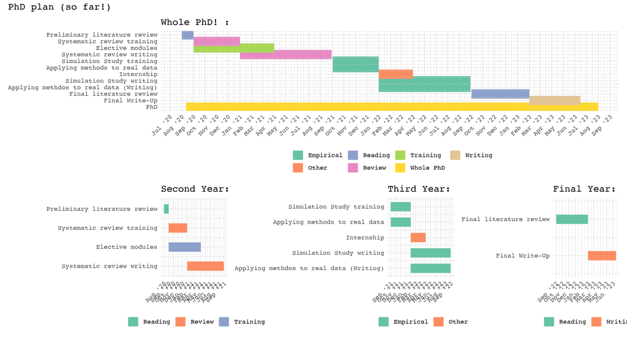